# Regression Analysis in Outcomes Research: A Practical Workshop

Outcomes Research Course

2026-03-24

## Learning Objectives

By the end of this workshop, you will be able to:

1. Identify exposure (X) and outcome (Y) variables in research questions
2. Understand the role of confounders in causal relationships
3. Prepare and explore data for regression analysis
4. Construct and interpret regression models in R
5. Interpret both continuous and categorical predictors across linear, logistic, and Poisson regression
6. Communicate statistical findings effectively
7. Recognize common biases and limitations in regression analysis

# Part 1: Conceptual Foundation

## 1.1 Understanding Relationships Between Variables

### The Research Question Framework

In outcomes research, we often ask: **“Does X affect Y?”**

- **Y (Outcome):** The dependent variable we want to understand or predict
- **X (Exposure/Predictor):** The independent variable(s) that may influence Y
- **Confounders:** Variables that affect both X and Y, potentially distorting the relationship

### Example Research Question

> **Does physical activity (X) improve sleep quality (Y)?**

[interactive chart not shown]

### Key Concept: Confounding

A **confounder** is a variable that is associated with both the exposure (X) and outcome (Y), but is NOT on the causal pathway between them.

Without adjusting for confounders, we might mistake correlation for causation. For example, people with higher stress might exercise less AND have poorer sleep quality, regardless of the true effect of physical activity on sleep.

## 1.2 Null and Alternative Hypotheses

Before analyzing data, we formulate **hypotheses** about the relationship between X and Y.

### The Null Hypothesis (H₀)

The **null hypothesis** states there is **no effect** or **no relationship**:

> H₀: Physical activity has no effect on sleep quality (β₁ = 0)

This is the “skeptic’s position” — we assume no effect until the data convinces us otherwise.

### The Alternative Hypothesis (H₁ or Hₐ)

The **alternative hypothesis** states there **is an effect**:

> H₁: Physical activity affects sleep quality (β₁ ≠ 0)

### How Regression Tests Hypotheses

When we run a regression, R automatically tests:

| What we test | Null Hypothesis | What p-value tells us |
| --- | --- | --- |
| Each coefficient | β = 0 (no effect) | Probability of seeing this result if H₀ is true |

- **p < 0.05:** Reject H₀ → Evidence of an effect (statistically significant)
- **p ≥ 0.05:** Fail to reject H₀ → Insufficient evidence of an effect

### Important Caveats

- **Statistical significance ≠ practical significance** — A 0.01 point increase in sleep quality might be statistically significant but not meaningful
- **Failing to reject H₀ ≠ proving no effect** — It may mean we lack power to detect it
- **p-values don’t tell us effect size** — Always report confidence intervals

## 1.3 The Regression Equation

Regression allows us to model the relationship between X and Y while adjusting for confounders.

### The Regression Equation

**Simple regression:** $Y = \beta_0 + \beta_1X + \epsilon$

**Multiple regression:** $Y = \beta_0 + \beta_1X_1 + \beta_2X_2 + ... + \beta_kX_k + \epsilon$

Multiple regression allows us to adjust for confounders by including them in the model.

# Part 2: Data Exploration & Preparation

## 2.1 Dataset Introduction

**Key Features:**

- **Comprehensive Sleep Metrics:** Sleep duration, quality of sleep, and sleep disorders
- **Lifestyle Factors:** Physical activity levels, stress levels, and BMI categories
- **Cardiovascular Health:** Blood pressure and heart rate measurements
- **Demographics:** Sex, age, and occupation

**Research Question:** Does physical activity level affect quality of sleep?

- **Outcome (Y):** Quality of Sleep (1-10 scale)
- **Exposure (X):** Physical Activity Level (minutes/day)
- **Potential Confounders:** Age, sex, stress level, BMI category

## 2.2 Load and Prepare Dataset

```r
# Load the dataset
data <- read_csv("Sleep_health_and_lifestyle_dataset.csv")

# Clean column names and prepare variables
data <- data %>%
  rename(
    person_id = `Person ID`,
    sleep_duration = `Sleep Duration`,
    quality_of_sleep = `Quality of Sleep`,
    physical_activity = `Physical Activity Level`,
    stress_level = `Stress Level`,
    bmi_category = `BMI Category`,
    blood_pressure = `Blood Pressure`,
    heart_rate = `Heart Rate`,
    daily_steps = `Daily Steps`,
    sleep_disorder = `Sleep Disorder`,
    # The dataset records biological sex (Male/Female), so we use Sex
    Sex = Gender
  ) %>%
  mutate(
    bmi_category = str_trim(bmi_category),
    bmi_category = case_when(
      bmi_category %in% c("Normal", "Normal Weight") ~ "Normal Weight",
      TRUE ~ bmi_category
    ),
    Sex = fct_relevel(factor(Sex), "Female"),
    bmi_category = fct_relevel(factor(bmi_category), "Normal Weight"),
    sleep_disorder = fct_relevel(factor(sleep_disorder), "None"),
    Occupation = factor(Occupation),
    high_activity = ifelse(physical_activity >= 60, 1, 0),
    high_activity_label = factor(
      ifelse(high_activity == 1, "High Activity", "Low Activity"),
      levels = c("Low Activity", "High Activity")
    ),
    age_group = cut(
      Age,
      breaks = c(0, 35, 45, 55, 100),
      labels = c("<35", "35-45", "46-55", ">55")
    )
  )

# Confirm the reference categories used in the workshop
levels(data$Sex)
```

```
## [1] "Female" "Male"
```

```r
levels(data$bmi_category)
```

```
## [1] "Normal Weight" "Obese"         "Overweight"
```

```r
levels(data$sleep_disorder)
```

```
## [1] "None"        "Insomnia"    "Sleep Apnea"
```

```r
# Preview the data
head(data) %>%
  select(person_id, Age, Sex, physical_activity, stress_level, quality_of_sleep)
```

```
## # A tibble: 6 × 6
##   person_id   Age Sex   physical_activity stress_level quality_of_sleep
##       <dbl> <dbl> <fct>             <dbl>        <dbl>            <dbl>
## 1         1    27 Male                 42            6                6
## 2         2    28 Male                 60            8                6
## 3         3    28 Male                 60            8                6
## 4         4    28 Male                 30            8                4
## 5         5    28 Male                 30            8                4
## 6         6    28 Male                 30            8                4
```

### Why Reference Categories Matter

For categorical variables, regression coefficients are always interpreted **relative to a reference category**. In this workshop, we explicitly set the following reference categories:

- `Sex`: **Female**
- `bmi_category`: **Normal Weight**
- `sleep_disorder`: **None**

This makes the model output easier to interpret than relying on the default alphabetical ordering.

## 2.3 Exploratory Data Analysis

```r
# Summary statistics
data %>%
  select(Age, physical_activity, stress_level, quality_of_sleep, sleep_duration) %>%
  summary()
```

```
##       Age        physical_activity  stress_level   quality_of_sleep
##  Min.   :27.00   Min.   :30.00     Min.   :3.000   Min.   :4.000
##  1st Qu.:35.25   1st Qu.:45.00     1st Qu.:4.000   1st Qu.:6.000
##  Median :43.00   Median :60.00     Median :5.000   Median :7.000
##  Mean   :42.18   Mean   :59.17     Mean   :5.385   Mean   :7.313
##  3rd Qu.:50.00   3rd Qu.:75.00     3rd Qu.:7.000   3rd Qu.:8.000
##  Max.   :59.00   Max.   :90.00     Max.   :8.000   Max.   :9.000
##  sleep_duration
##  Min.   :5.800
##  1st Qu.:6.400
##  Median :7.200
##  Mean   :7.132
##  3rd Qu.:7.800
##  Max.   :8.500
```

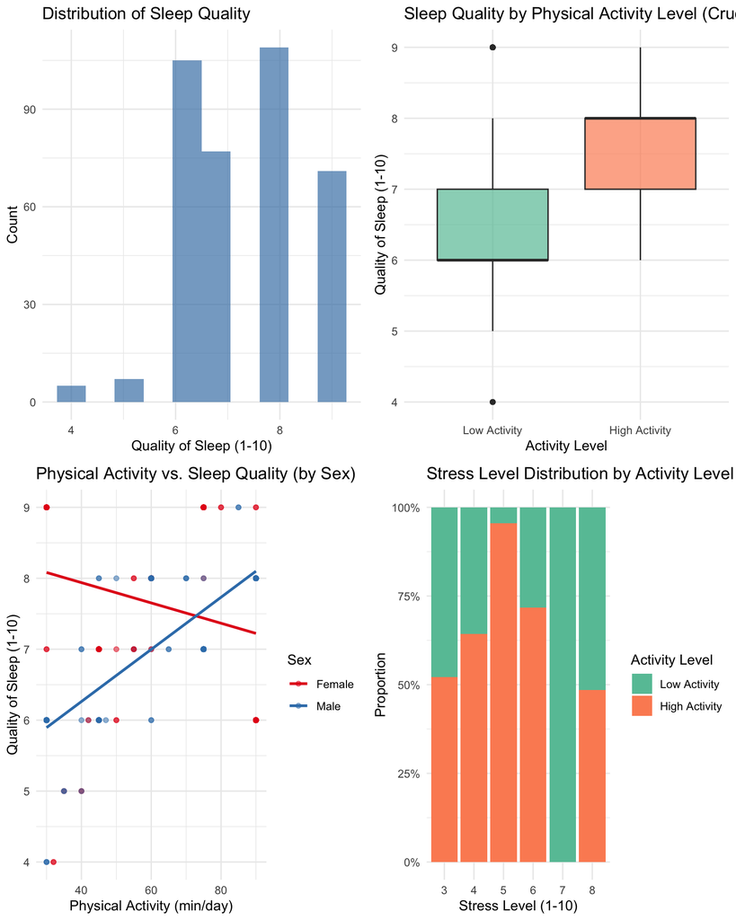

```r
# 1. Distribution of outcome (quality of sleep)
p1 <- ggplot(data, aes(x = quality_of_sleep)) +
  geom_histogram(bins = 10, fill = "steelblue", alpha = 0.7) +
  labs(
    title = "Distribution of Sleep Quality",
    x = "Quality of Sleep (1-10)",
    y = "Count"
  ) +
  theme_minimal()

# 2. Sleep quality by activity level (crude comparison)
p2 <- ggplot(data, aes(
  x = high_activity_label,
  y = quality_of_sleep,
  fill = high_activity_label
)) +
  geom_boxplot(alpha = 0.7) +
  labs(
    title = "Sleep Quality by Physical Activity Level (Crude Comparison)",
    x = "Activity Level",
    y = "Quality of Sleep (1-10)"
  ) +
  theme_minimal() +
  theme(legend.position = "none") +
  scale_fill_brewer(palette = "Set2")

# 3. Relationship between physical activity and sleep quality
p3 <- ggplot(data, aes(x = physical_activity, y = quality_of_sleep, color = Sex)) +
  geom_point(alpha = 0.5) +
  geom_smooth(method = "lm", se = FALSE) +
  labs(
    title = "Physical Activity vs. Sleep Quality (by Sex)",
    x = "Physical Activity (min/day)",
    y = "Quality of Sleep (1-10)",
    color = "Sex"
  ) +
  theme_minimal() +
  scale_color_brewer(palette = "Set1")

# 4. Stress level distribution by activity level
p4 <- ggplot(data, aes(x = factor(stress_level), fill = high_activity_label)) +
  geom_bar(position = "fill") +
  labs(
    title = "Stress Level Distribution by Activity Level",
    x = "Stress Level (1-10)",
    y = "Proportion",
    fill = "Activity Level"
  ) +
  theme_minimal() +
  scale_fill_brewer(palette = "Set2") +
  scale_y_continuous(labels = scales::percent)

# Display all plots
grid.arrange(p1, p2, p3, p4, ncol = 2)
```

### Discussion Question

Look at the plots above. What do you observe about the relationship between physical activity and sleep quality? Why might a simple comparison be misleading?

# Part 3: Building Regression Models

## 3.1 Simple Comparison (Crude Analysis)

First, let’s look at the unadjusted difference in means.

```r
# Calculate mean difference
mean_diff <- data %>%
  group_by(high_activity_label) %>%
  summarise(mean_sleep_quality = mean(quality_of_sleep), .groups = "drop") %>%
  pivot_wider(
    names_from = high_activity_label,
    values_from = mean_sleep_quality
  ) %>%
  mutate(difference = `High Activity` - `Low Activity`)

print(mean_diff)
```

```
## # A tibble: 1 × 3
##   `Low Activity` `High Activity` difference
##            <dbl>           <dbl>      <dbl>
## 1           6.81            7.69      0.887
```

The crude analysis shows people with high physical activity have better sleep quality. But is this the true effect or could there be confounding?

## 3.2 Simple Linear Regression

Now let’s use regression to estimate the effect.

```r
# Fit simple linear regression
model_simple <- lm(quality_of_sleep ~ physical_activity, data = data)

# Display results
summary(model_simple)
```

```
##
## Call:
## lm(formula = quality_of_sleep ~ physical_activity, data = data)
##
## Residuals:
##     Min      1Q  Median      3Q     Max
## -3.0117 -0.9895 -0.1558  0.6780  2.0105
##
## Coefficients:
##                   Estimate Std. Error t value Pr(>|t|)
## (Intercept)       6.656982   0.183351  36.307  < 2e-16 ***
## physical_activity 0.011084   0.002923   3.792 0.000175 ***
## ---
## Signif. codes:  0 '***' 0.001 '**' 0.01 '*' 0.05 '.' 0.1 ' ' 1
##
## Residual standard error: 1.176 on 372 degrees of freedom
## Multiple R-squared:  0.03721,    Adjusted R-squared:  0.03462
## F-statistic: 14.38 on 1 and 372 DF,  p-value: 0.0001745
```

```r
# Tidy format
tidy_simple <- tidy(model_simple, conf.int = TRUE) %>%
  mutate(across(where(is.numeric), ~ round(., 3)))

print(tidy_simple)
```

```
## # A tibble: 2 × 7
##   term              estimate std.error statistic p.value conf.low conf.high
##   <chr>                <dbl>     <dbl>     <dbl>   <dbl>    <dbl>     <dbl>
## 1 (Intercept)          6.66      0.183     36.3        0    6.30      7.02
## 2 physical_activity    0.011     0.003      3.79       0    0.005     0.017
```

**Key outputs:**

- **Coefficient:** Estimated effect on sleep quality per minute of physical activity
- **95% CI:** Range of plausible values
- **p-value:** Statistical significance

### Sleep Quality by Sex

Let’s also examine the relationship between sex and sleep quality.

```r
# Compare sleep quality by sex
data %>%
  group_by(Sex) %>%
  summarise(
    n = n(),
    mean_quality = mean(quality_of_sleep),
    sd_quality = sd(quality_of_sleep),
    .groups = "drop"
  )
```

```
## # A tibble: 2 × 4
##   Sex        n mean_quality sd_quality
##   <fct>  <int>        <dbl>      <dbl>
## 1 Female   185         7.66      1.28
## 2 Male     189         6.97      0.999
```

```r
# Simple regression with sex as predictor
model_sex <- lm(quality_of_sleep ~ Sex, data = data)
summary(model_sex)
```

```
##
## Call:
## lm(formula = quality_of_sleep ~ Sex, data = data)
##
## Residuals:
##     Min      1Q  Median      3Q     Max
## -3.6649 -0.9683  0.0317  1.0317  2.0317
##
## Coefficients:
##             Estimate Std. Error t value Pr(>|t|)
## (Intercept)   7.6649     0.0843  90.927  < 2e-16 ***
## SexMale      -0.6966     0.1186  -5.875 9.42e-09 ***
## ---
## Signif. codes:  0 '***' 0.001 '**' 0.01 '*' 0.05 '.' 0.1 ' ' 1
##
## Residual standard error: 1.147 on 372 degrees of freedom
## Multiple R-squared:  0.08489,    Adjusted R-squared:  0.08243
## F-statistic: 34.51 on 1 and 372 DF,  p-value: 9.416e-09
```

**Interpretation:** The coefficient for `SexMale` tells us the average difference in sleep quality between males and females. Because Female is the reference category, `SexMale` is interpreted as:

> average sleep quality among males minus average sleep quality among females

This idea will carry forward when we interpret categorical variables in multiple linear, logistic, and Poisson regression.

## 3.3 Multiple Linear Regression (Adjusting for Confounders)

Now let’s adjust for confounders to get a better estimate of the effect.

```r
# Fit multiple regression model
model_adjusted <- lm(
  quality_of_sleep ~ physical_activity + Age + Sex + stress_level + bmi_category,
  data = data
)

# Display results
summary(model_adjusted)
```

```
##
## Call:
## lm(formula = quality_of_sleep ~ physical_activity + Age + Sex +
##     stress_level + bmi_category, data = data)
##
## Residuals:
##     Min      1Q  Median      3Q     Max
## -1.0394 -0.1618 -0.0069  0.1557  1.0962
##
## Coefficients:
##                          Estimate Std. Error t value Pr(>|t|)
## (Intercept)             7.2885990  0.1515558  48.092  < 2e-16 ***
## physical_activity       0.0069110  0.0007568   9.132  < 2e-16 ***
## Age                     0.0572807  0.0028245  20.280  < 2e-16 ***
## SexMale                 0.2785881  0.0401297   6.942 1.76e-11 ***
## stress_level           -0.4736614  0.0114197 -41.478  < 2e-16 ***
## bmi_categoryObese      -0.9962315  0.0964505 -10.329  < 2e-16 ***
## bmi_categoryOverweight -0.9211587  0.0437364 -21.062  < 2e-16 ***
## ---
## Signif. codes:  0 '***' 0.001 '**' 0.01 '*' 0.05 '.' 0.1 ' ' 1
##
## Residual standard error: 0.2964 on 367 degrees of freedom
## Multiple R-squared:  0.9397, Adjusted R-squared:  0.9387
## F-statistic: 952.8 on 6 and 367 DF,  p-value: < 2.2e-16
```

```r
# Tidy format
tidy_adjusted <- tidy(model_adjusted, conf.int = TRUE) %>%
  mutate(across(where(is.numeric), ~ round(., 3)))

print(tidy_adjusted)
```

```
## # A tibble: 7 × 7
##   term                   estimate std.error statistic p.value conf.low conf.high
##   <chr>                     <dbl>     <dbl>     <dbl>   <dbl>    <dbl>     <dbl>
## 1 (Intercept)               7.29      0.152     48.1        0    6.99      7.59
## 2 physical_activity         0.007     0.001      9.13       0    0.005     0.008
## 3 Age                       0.057     0.003     20.3        0    0.052     0.063
## 4 SexMale                   0.279     0.04       6.94       0    0.2       0.358
## 5 stress_level             -0.474     0.011    -41.5        0   -0.496    -0.451
## 6 bmi_categoryObese        -0.996     0.096    -10.3        0   -1.19     -0.807
## 7 bmi_categoryOverweight   -0.921     0.044    -21.1        0   -1.01     -0.835
```

**Interpreting coefficients:**

- **Continuous variables** (e.g., `physical_activity`, `Age`, `stress_level`): Each coefficient represents the expected change in sleep quality for a 1-unit increase in that predictor, **holding all other variables constant**.
- **Binary categorical variables** (e.g., `Sex`): The coefficient compares the mean outcome for one category versus the reference category.
  - `SexMale`: the average difference in sleep quality for males compared with females, adjusting for the other covariates
- **Multi-level categorical variables** (e.g., `bmi_category`): Each coefficient compares one category to the chosen reference group.
  - `bmi_categoryOverweight`: the average difference in sleep quality for overweight individuals compared with those of normal weight
  - `bmi_categoryObese`: the average difference in sleep quality for individuals with obesity compared with those of normal weight

For example, if the coefficient for `SexMale` were -0.40, we would say:

> After adjusting for physical activity, age, stress level, and BMI category, males had an average sleep quality score that was 0.40 points lower than females.

If the coefficient for `bmi_categoryObese` were -1.10, we would say:

> After adjustment, individuals with obesity had an average sleep quality score 1.10 points lower than individuals with normal weight.

## 3.4 Interpreting Categorical Predictors Across Regression Models

Many predictors in outcomes research are **categorical**, such as sex, BMI category, occupation, or disease status.

### Reference categories

When a categorical variable is included in a regression model, R creates indicator variables and compares each category to a **reference category**.

For example, if `Sex` has two categories:

- **Female** = reference category
- `SexMale` = comparison category

then the coefficient for `SexMale` tells us how males differ from females, **holding all other variables constant**.

For variables with more than two categories, such as `bmi_category`, R creates one coefficient for each non-reference level:

- `bmi_categoryOverweight`: compares overweight to normal weight
- `bmi_categoryObese`: compares obesity to normal weight

### General interpretation rule

- **Linear regression:** coefficient = difference in the **mean outcome** compared with the reference group
- **Logistic regression:** exp(coefficient) = **odds ratio** compared with the reference group
- **Poisson regression:** exp(coefficient) = **rate ratio** or **incidence rate ratio (IRR)** compared with the reference group

### Template language

For a categorical predictor, you can usually write:

- **Linear:** “Compared with [reference], those in [category] had an average outcome that was β units higher/lower.”
- **Logistic:** “Compared with [reference], those in [category] had OR times the odds of the outcome.”
- **Poisson:** “Compared with [reference], those in [category] had IRR times the expected count/rate of the outcome.”

> **Important:** For a categorical variable with several levels (such as BMI category or occupation), each coefficient compares one level with the reference group. You can also test the variable **overall** to ask whether the categories differ as a whole.

## 3.5 Comparing Models

```r
# Compare coefficient estimates
comparison <- bind_rows(
  tidy_simple %>%
    filter(term == "physical_activity") %>%
    mutate(Model = "Unadjusted"),
  tidy_adjusted %>%
    filter(term == "physical_activity") %>%
    mutate(Model = "Adjusted")
) %>%
  select(Model, estimate, conf.low, conf.high, p.value)

print(comparison)
```

```
## # A tibble: 2 × 5
##   Model      estimate conf.low conf.high p.value
##   <chr>         <dbl>    <dbl>     <dbl>   <dbl>
## 1 Unadjusted    0.011    0.005     0.017       0
## 2 Adjusted      0.007    0.005     0.008       0
```

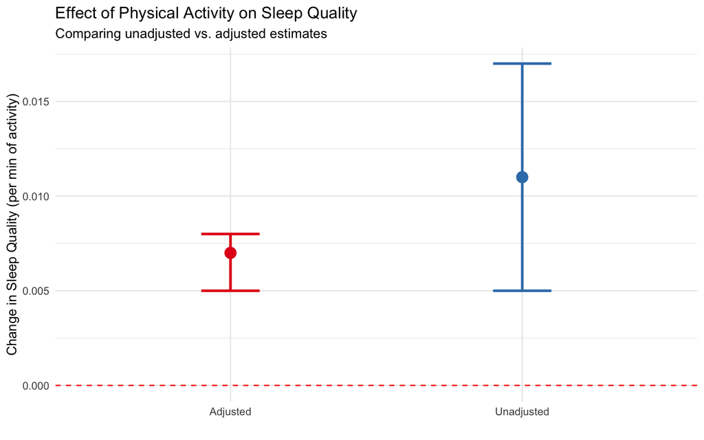

```r
# Visualize the comparison
ggplot(comparison, aes(x = Model, y = estimate, color = Model)) +
  geom_point(size = 4) +
  geom_errorbar(
    aes(ymin = conf.low, ymax = conf.high),
    width = 0.2,
    linewidth = 1
  ) +
  geom_hline(yintercept = 0, linetype = "dashed", color = "red") +
  labs(
    title = "Effect of Physical Activity on Sleep Quality",
    subtitle = "Comparing unadjusted vs. adjusted estimates",
    y = "Change in Sleep Quality (per min of activity)",
    x = ""
  ) +
  theme_minimal() +
  scale_color_brewer(palette = "Set1") +
  theme(legend.position = "none")
```

### Critical Insight

**Unadjusted:** Each additional minute of physical activity is associated with a 0.011 point increase in sleep quality.

**Adjusted:** After controlling for age, sex, stress, and BMI, each additional minute of physical activity is associated with a 0.007 point increase in sleep quality.

Adjusting for confounders helps isolate the effect of physical activity.

## 3.6 Beyond Linear Regression: Logistic and Poisson

Linear regression works for **continuous outcomes**. For other outcome types, we use different regression models:

| Outcome Type | Example | Regression Type | R Function |
| --- | --- | --- | --- |
| Continuous | Sleep quality score | Linear | `lm()` |
| Binary (Yes/No) | Sleep disorder | Logistic | `glm(..., family = binomial)` |
| Count | Daily steps (thousands) | Poisson | `glm(..., family = poisson)` |

### Logistic Regression (Binary Outcomes)

```r
# Create a binary outcome: Does the person have a sleep disorder?
data <- data %>%
  mutate(has_disorder = ifelse(sleep_disorder != "None", 1, 0))

# Fit logistic regression including categorical predictors
model_logistic <- glm(
  has_disorder ~ physical_activity + Age + Sex + stress_level + bmi_category,
  data = data,
  family = binomial
)

# View results - coefficients are log-odds
tidy(model_logistic, conf.int = TRUE) %>%
  mutate(across(where(is.numeric), ~ round(., 3)))
```

```
## # A tibble: 7 × 7
##   term                   estimate std.error statistic p.value conf.low conf.high
##   <chr>                     <dbl>     <dbl>     <dbl>   <dbl>    <dbl>     <dbl>
## 1 (Intercept)              -7.50      1.95     -3.84    0      -11.5      -3.81
## 2 physical_activity         0.004     0.01      0.417   0.677   -0.016     0.026
## 3 Age                       0.068     0.032     2.09    0.036    0.004     0.132
## 4 SexMale                  -1.06      0.53     -2.00    0.046   -2.13     -0.037
## 5 stress_level              0.52      0.171     3.04    0.002    0.209     0.884
## 6 bmi_categoryObese        20.3    1232.        0.016   0.987  -74.3      NA
## 7 bmi_categoryOverweight    3.54      0.42      8.44    0        2.75      4.41
```

**Exponentiate to get Odds Ratios:**

```r
logistic_or <- tidy(model_logistic, conf.int = TRUE, exponentiate = TRUE) %>%
  mutate(across(where(is.numeric), ~ round(., 2))) %>%
  select(term, OR = estimate, conf.low, conf.high, p.value)

print(logistic_or)
```

```
## # A tibble: 7 × 5
##   term                             OR conf.low conf.high p.value
##   <chr>                         <dbl>    <dbl>     <dbl>   <dbl>
## 1 (Intercept)                    0        0         0.02    0
## 2 physical_activity              1        0.98      1.03    0.68
## 3 Age                            1.07     1         1.14    0.04
## 4 SexMale                        0.35     0.12      0.96    0.05
## 5 stress_level                   1.68     1.23      2.42    0
## 6 bmi_categoryObese      659046891.       0        NA       0.99
## 7 bmi_categoryOverweight        34.6     15.7      82.2     0
```

**Interpreting categorical variables in logistic regression:**

After exponentiating the coefficients, categorical predictors are interpreted as **odds ratios relative to the reference category**.

- `SexMale`: the odds ratio comparing males with females
- `bmi_categoryOverweight`: the odds ratio comparing overweight individuals with those of normal weight
- `bmi_categoryObese`: the odds ratio comparing individuals with obesity with those of normal weight

For example:

- If `SexMale` has OR = 1.40, males have **1.40 times the odds** of a sleep disorder compared with females, adjusting for the other variables.
- If `bmi_categoryObese` has OR = 2.10, individuals with obesity have **2.10 times the odds** of a sleep disorder compared with those of normal weight.

An OR greater than 1 indicates **higher odds** than the reference group; an OR less than 1 indicates **lower odds**.

**Continuous predictor reminder:** An OR of 1 for physical activity means that for each additional minute of daily physical activity, the odds of having a sleep disorder change by a factor of 1, adjusting for age, sex, stress level, and BMI category.

### Poisson Regression (Count Outcomes)

```r
# Use daily steps as a count-like outcome (scaled to thousands)
data <- data %>%
  mutate(steps_thousands = round(daily_steps / 1000))

# Fit Poisson regression including categorical predictors
model_poisson <- glm(
  steps_thousands ~ physical_activity + Age + Sex + stress_level + bmi_category,
  data = data,
  family = poisson
)

# Exponentiate to get incidence rate ratios (IRR)
poisson_irr <- tidy(model_poisson, conf.int = TRUE, exponentiate = TRUE) %>%
  mutate(across(where(is.numeric), ~ round(., 2))) %>%
  select(term, IRR = estimate, conf.low, conf.high, p.value)

print(poisson_irr)
```

```
## # A tibble: 7 × 5
##   term                     IRR conf.low conf.high p.value
##   <chr>                  <dbl>    <dbl>     <dbl>   <dbl>
## 1 (Intercept)             3.77     2.57      5.52    0
## 2 physical_activity       1.01     1.01      1.01    0
## 3 Age                     1        0.99      1.01    0.73
## 4 SexMale                 0.95     0.86      1.05    0.34
## 5 stress_level            1.03     1         1.06    0.04
## 6 bmi_categoryObese       0.52     0.37      0.72    0
## 7 bmi_categoryOverweight  0.96     0.85      1.08    0.5
```

**Interpreting categorical variables in Poisson regression:**

After exponentiating the coefficients, categorical predictors are interpreted as **rate ratios** or **incidence rate ratios (IRRs)** relative to the reference category.

- `SexMale`: the expected step count for males relative to females
- `bmi_categoryOverweight`: the expected step count for overweight individuals relative to those of normal weight
- `bmi_categoryObese`: the expected step count for individuals with obesity relative to those of normal weight

For example:

- If `SexMale` has IRR = 1.12, males have an expected daily step count that is **12% higher** than females, adjusting for the other covariates.
- If `bmi_categoryObese` has IRR = 0.88, individuals with obesity have an expected daily step count that is **12% lower** than those of normal weight.

An IRR above 1 means a **higher expected count/rate** than the reference group; an IRR below 1 means a **lower expected count/rate**.

**Continuous predictor reminder:** An IRR of 1.01 for physical activity means each additional minute of physical activity is associated with a 0.9% change in the expected daily step count.

### Quick Comparison: Interpreting Categorical Predictors Across Models

| Model type | Example coefficient | What it compares | Interpretation |
| --- | --- | --- | --- |
| Linear | `SexMale = -0.40` | Male vs Female | Males have an average sleep quality score 0.40 points lower than females |
| Logistic | `exp(SexMale) = 1.40` | Male vs Female | Males have 1.40 times the odds of sleep disorder compared with females |
| Poisson | `exp(SexMale) = 1.12` | Male vs Female | Males have an expected step count 12% higher than females |
| Linear | `bmi_categoryObese = -1.10` | Obese vs Normal Weight | Individuals with obesity have average sleep quality 1.10 points lower |
| Logistic | `exp(bmi_categoryObese) = 2.10` | Obese vs Normal Weight | Individuals with obesity have 2.10 times the odds of sleep disorder |
| Poisson | `exp(bmi_categoryObese) = 0.88` | Obese vs Normal Weight | Individuals with obesity have an expected step count 12% lower |

### Key Takeaway

- **Linear:** coefficient = change in Y for 1-unit change in X; for categorical predictors, the coefficient is a difference in mean outcome vs the reference group
- **Logistic:** exp(coefficient) = **Odds Ratio**; for categorical predictors, the OR compares each category with the reference group
- **Poisson:** exp(coefficient) = **Rate Ratio / IRR**; for categorical predictors, the IRR compares each category with the reference group

> **Quick rule:** Always identify the **reference category first** before interpreting any categorical coefficient.

> **Note:** In practice, we also assess goodness of fit (R², AIC/BIC) and check model assumptions (linearity, normality of residuals, homoscedasticity, and appropriate mean-variance structure) before finalizing our conclusions.

# Part 4: Communicating Results

## 4.1 Publication-Ready Tables

```r
# Create a professional results table
results_table <- tidy_adjusted %>%
  mutate(
    `95% CI` = paste0(
      "(",
      sprintf("%.3f", conf.low),
      " to ",
      sprintf("%.3f", conf.high),
      ")"
    ),
    Variable = case_when(
      term == "(Intercept)" ~ "Intercept",
      term == "physical_activity" ~ "Physical Activity (per min/day)",
      term == "Age" ~ "Age (per year)",
      term == "SexMale" ~ "Sex: Male (vs Female)",
      term == "stress_level" ~ "Stress Level (per unit)",
      term == "bmi_categoryOverweight" ~ "BMI: Overweight (vs Normal Weight)",
      term == "bmi_categoryObese" ~ "BMI: Obese (vs Normal Weight)",
      TRUE ~ term
    )
  ) %>%
  select(Variable, Coefficient = estimate, `95% CI`, `p-value` = p.value)

kable(
  results_table,
  caption = "Table 1. Multiple Linear Regression Results: Predictors of Sleep Quality",
  digits = 3
)
```

Table 1. Multiple Linear Regression Results: Predictors of Sleep Quality

| Variable | Coefficient | 95% CI | p-value |
| --- | --- | --- | --- |
| Intercept | 7.289 | (6.991 to 7.587) | 0 |
| Physical Activity (per min/day) | 0.007 | (0.005 to 0.008) | 0 |
| Age (per year) | 0.057 | (0.052 to 0.063) | 0 |
| Sex: Male (vs Female) | 0.279 | (0.200 to 0.358) | 0 |
| Stress Level (per unit) | -0.474 | (-0.496 to -0.451) | 0 |
| BMI: Obese (vs Normal Weight) | -0.996 | (-1.186 to -0.807) | 0 |
| BMI: Overweight (vs Normal Weight) | -0.921 | (-1.007 to -0.835) | 0 |

## 4.2 Writing Results

“After adjusting for age, sex, stress level, and BMI category, physical activity was associated with a 0.007 point increase in sleep quality per additional minute of daily activity (95% CI: 0.005 to 0.008, p < <2e-16).”

If you want to describe a categorical predictor, use the same logic but reference the comparison group. For example:

“After adjustment, males had a sleep quality score of 0.279 points different from females (95% CI: 0.2 to 0.358), holding physical activity, age, stress level, and BMI category constant.”

# Part 5: Hands-On Practice

## 5.1 Practice Exercise

**New Research Question:** Does stress level affect sleep duration?

Using the same Sleep Health and Lifestyle dataset, explore a different relationship:

- **Outcome (Y):** Sleep Duration (hours)
- **Exposure (X):** Stress Level (1-10 scale)
- **Potential Confounders:** Age, physical activity, occupation

```r
# Preview relevant variables for practice
head(data, 10) %>%
  select(person_id, Age, Occupation, sleep_duration, stress_level, physical_activity)
```

```
## # A tibble: 10 × 6
##    person_id   Age Occupation      sleep_duration stress_level physical_activity
##        <dbl> <dbl> <fct>                    <dbl>        <dbl>             <dbl>
##  1         1    27 Software Engin…            6.1            6                42
##  2         2    28 Doctor                     6.2            8                60
##  3         3    28 Doctor                     6.2            8                60
##  4         4    28 Sales Represen…            5.9            8                30
##  5         5    28 Sales Represen…            5.9            8                30
##  6         6    28 Software Engin…            5.9            8                30
##  7         7    29 Teacher                    6.3            7                40
##  8         8    29 Doctor                     7.8            6                75
##  9         9    29 Doctor                     7.8            6                75
## 10        10    29 Doctor                     7.8            6                75
```

## 5.2 Your Tasks

### Step 1: Explore the Data

```r
# YOUR CODE HERE

# 1. Calculate summary statistics for sleep duration by stress level groups
#    Hint: Create stress categories (low: 1-3, medium: 4-6, high: 7-10)

# 2. Create visualizations:
#    - Distribution of sleep duration
#    - Sleep duration by stress level (scatterplot)
#    - Box plot of sleep duration by stress categories

# 3. Explore potential confounders:
#    How do Age, physical activity, and Occupation relate to stress?
```

**Hints:** Use `summary()`, `group_by()`, `ggplot()`, and think about whether any categorical predictors (such as `Occupation`) need a reference group for interpretation.

### Step 2: Fit Regression Models

```r
# YOUR CODE HERE

# 1. Fit a simple regression: sleep_duration ~ stress_level

# 2. Fit a multiple regression adjusting for potential confounders
#    Consider including: Age, physical_activity, Occupation

# 3. Compare the stress_level coefficients between models

# 4. If you include Occupation, identify the reference category and
#    explain how you would interpret one Occupation coefficient
```

**Hints:** Use `lm()` and `tidy()`. If you include a categorical variable, remember that each coefficient compares one level with the reference category.

### Step 3: Interpret Results

```r
# YOUR CODE HERE

# 1. Create a comparison table of unadjusted vs adjusted estimates for stress_level

# 2. Visualize the effect estimates with confidence intervals

# 3. Write a one-sentence interpretation of your findings

# 4. Optional:
#    Write one sentence interpreting an Occupation coefficient
```

**Answer:** What’s the crude vs. adjusted effect of stress on sleep duration? Did confounding matter? What are the limitations?

## 5.3 Solution (Reveal After Attempting)

**Click to reveal solution**

```r
# STEP 1: Explore the data

# Create stress categories
data <- data %>%
  mutate(stress_category = case_when(
    stress_level <= 3 ~ "Low (1-3)",
    stress_level <= 6 ~ "Medium (4-6)",
    TRUE ~ "High (7-10)"
  ))

# Set a reference category for Occupation if desired
data <- data %>%
  mutate(Occupation = fct_relevel(Occupation, levels(Occupation)[1]))

# Summary statistics
data %>%
  group_by(stress_category) %>%
  summarise(
    n = n(),
    mean_sleep = mean(sleep_duration),
    sd_sleep = sd(sleep_duration),
    mean_age = mean(Age),
    mean_activity = mean(physical_activity),
    .groups = "drop"
  )
```

```
## # A tibble: 3 × 6
##   stress_category     n mean_sleep sd_sleep mean_age mean_activity
##   <chr>           <int>      <dbl>    <dbl>    <dbl>         <dbl>
## 1 High (7-10)       120       6.22    0.238     41.0          52.3
## 2 Low (1-3)          71       8.23    0.219     54.2          54.7
## 3 Medium (4-6)      183       7.30    0.449     38.3          65.4
```

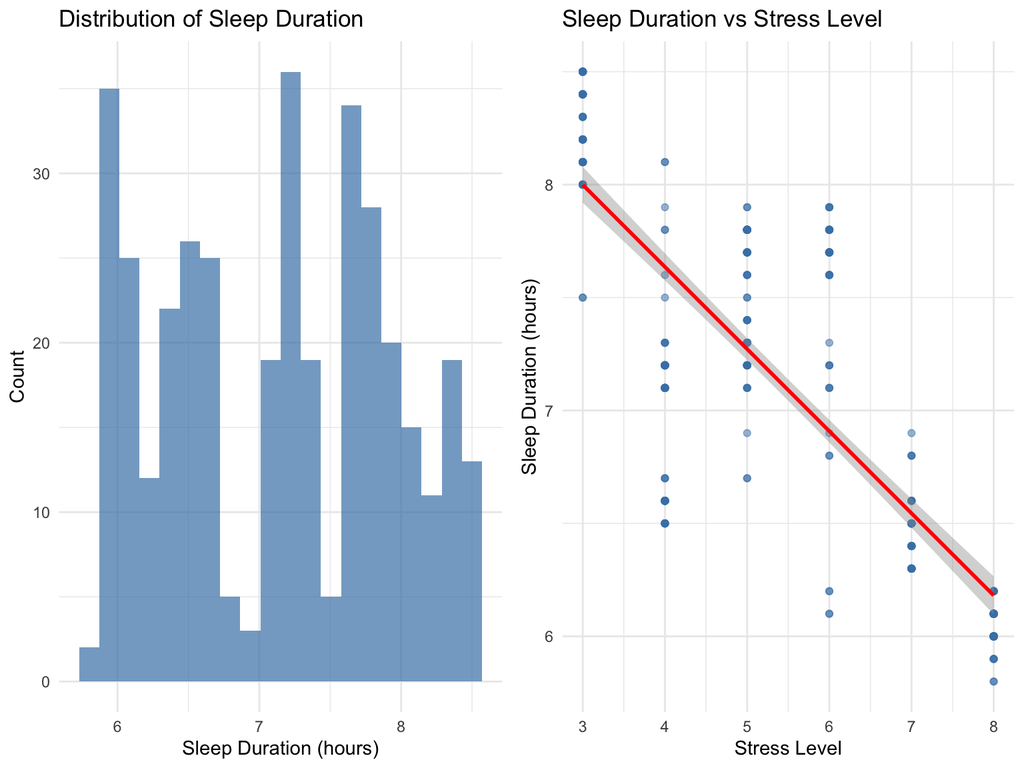

```r
# Visualizations
p1 <- ggplot(data, aes(x = sleep_duration)) +
  geom_histogram(bins = 20, fill = "steelblue", alpha = 0.7) +
  labs(
    title = "Distribution of Sleep Duration",
    x = "Sleep Duration (hours)",
    y = "Count"
  ) +
  theme_minimal()

p2 <- ggplot(data, aes(x = stress_level, y = sleep_duration)) +
  geom_point(alpha = 0.5, color = "steelblue") +
  geom_smooth(method = "lm", se = TRUE, color = "red") +
  labs(
    title = "Sleep Duration vs Stress Level",
    x = "Stress Level",
    y = "Sleep Duration (hours)"
  ) +
  theme_minimal()

grid.arrange(p1, p2, ncol = 2)
```

```r
# STEP 2: Fit regression models

# Simple model
model_practice_simple <- lm(sleep_duration ~ stress_level, data = data)
tidy(model_practice_simple, conf.int = TRUE) %>%
  mutate(across(where(is.numeric), ~ round(., 3)))
```

```
## # A tibble: 2 × 7
##   term         estimate std.error statistic p.value conf.low conf.high
##   <chr>           <dbl>     <dbl>     <dbl>   <dbl>    <dbl>     <dbl>
## 1 (Intercept)     9.09      0.077     118.        0     8.94     9.24
## 2 stress_level   -0.364     0.014     -26.7       0    -0.39    -0.337
```

```r
# Adjusted model with a categorical covariate
model_practice_adjusted <- lm(
  sleep_duration ~ stress_level + Age + physical_activity + Occupation,
  data = data
)
tidy(model_practice_adjusted, conf.int = TRUE) %>%
  mutate(across(where(is.numeric), ~ round(., 3)))
```

```
## # A tibble: 14 × 7
##    term                  estimate std.error statistic p.value conf.low conf.high
##    <chr>                    <dbl>     <dbl>     <dbl>   <dbl>    <dbl>     <dbl>
##  1 (Intercept)              8.08      0.171    47.3     0        7.75      8.42
##  2 stress_level            -0.376     0.012   -31.4     0       -0.399    -0.352
##  3 Age                      0.009     0.003     2.86    0.004    0.003     0.014
##  4 physical_activity        0.007     0.001     8.01    0        0.005     0.009
##  5 OccupationDoctor         0.739     0.064    11.5     0        0.612     0.866
##  6 OccupationEngineer       0.594     0.064     9.35    0        0.469     0.719
##  7 OccupationLawyer         0.386     0.066     5.90    0        0.257     0.515
##  8 OccupationManager       -0.085     0.297    -0.285   0.775   -0.669     0.499
##  9 OccupationNurse          0.056     0.076     0.736   0.462   -0.094     0.206
## 10 OccupationSales Repr…    0.367     0.218     1.69    0.092   -0.061     0.796
## 11 OccupationSalesperson    0.254     0.079     3.2     0.001    0.098     0.41
## 12 OccupationScientist     -0.034     0.157    -0.22    0.826   -0.343     0.274
## 13 OccupationSoftware E…    0.309     0.156     1.98    0.049    0.002     0.616
## 14 OccupationTeacher       -0.378     0.068    -5.57    0       -0.511    -0.244
```

```r
# STEP 3: Compare and visualize

comparison_practice <- bind_rows(
  tidy(model_practice_simple, conf.int = TRUE) %>%
    filter(term == "stress_level") %>%
    mutate(Model = "Unadjusted"),
  tidy(model_practice_adjusted, conf.int = TRUE) %>%
    filter(term == "stress_level") %>%
    mutate(Model = "Adjusted")
) %>%
  select(Model, estimate, conf.low, conf.high, p.value)

print(comparison_practice)
```

```
## # A tibble: 2 × 5
##   Model      estimate conf.low conf.high   p.value
##   <chr>         <dbl>    <dbl>     <dbl>     <dbl>
## 1 Unadjusted   -0.364   -0.390    -0.337 1.24e- 88
## 2 Adjusted     -0.376   -0.399    -0.352 3.38e-105
```

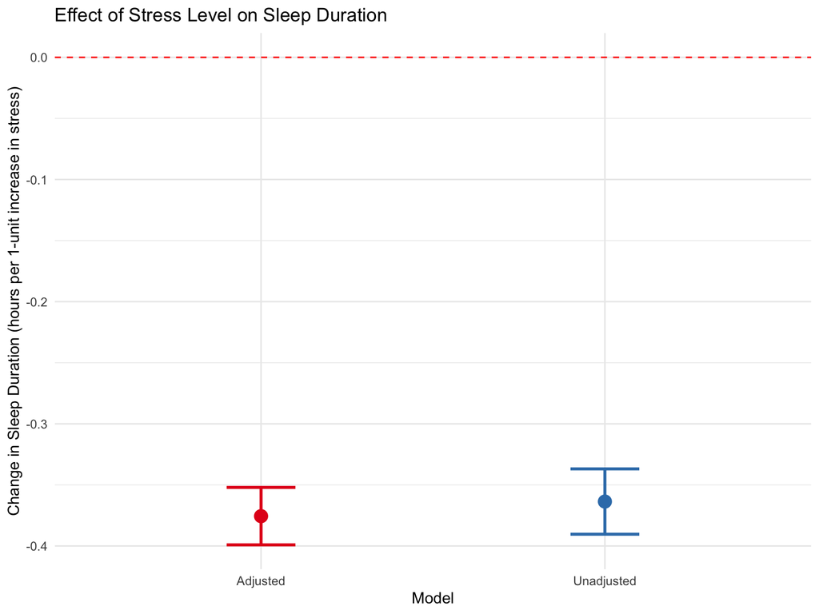

```r
# Forest plot
ggplot(comparison_practice, aes(x = Model, y = estimate, color = Model)) +
  geom_point(size = 4) +
  geom_errorbar(
    aes(ymin = conf.low, ymax = conf.high),
    width = 0.2,
    linewidth = 1
  ) +
  geom_hline(yintercept = 0, linetype = "dashed", color = "red") +
  labs(
    title = "Effect of Stress Level on Sleep Duration",
    y = "Change in Sleep Duration (hours per 1-unit increase in stress)"
  ) +
  theme_minimal() +
  scale_color_brewer(palette = "Set1") +
  theme(legend.position = "none")
```

**Interpretation:** After adjusting for age, physical activity, and occupation, each 1-point increase in stress level was associated with a -0.38 hour change in sleep duration (95% CI: -0.4 to -0.35).

If you included a categorical predictor such as `Occupation`, each Occupation coefficient would be interpreted as the mean difference in sleep duration compared with the chosen reference occupation, holding the other variables constant.

# Part 6: Key Takeaways & Resources

## 6.1 Key Takeaways

**Concepts:**

- Identify X (exposure), Y (outcome), and confounders
- Understand how confounding distorts relationships
- Use regression to adjust for confounders
- Interpret continuous predictors as changes per unit increase
- Interpret categorical predictors relative to a reference group

**Skills:**

- Explore data and visualize relationships
- Fit and interpret regression models in R
- Compare crude vs. adjusted estimates
- Interpret categorical variables in linear, logistic, and Poisson models
- Create tables and communicate findings

## 6.2 Common Pitfalls to Avoid

[output not shown]

# Appendix: Quick R Reference

```r
# Fit regression
model <- lm(y ~ x1 + x2, data = data)

# View results
summary(model)                    # Full output
tidy(model, conf.int = TRUE)      # Clean table (broom)
glance(model)                     # Model fit stats

# Diagnostics
plot(model)                       # Check assumptions

# Set a reference category for a factor
data$group <- forcats::fct_relevel(data$group, "Reference Level")

# Logistic or Poisson: exponentiate for OR / IRR
tidy(model, conf.int = TRUE, exponentiate = TRUE)
```